# Data Visualization

### Readme

This data set includes information about individual bike sharing rides made in a bike-sharing system covering the greater San Francisco Bay area.

The distance traveled and the duration of the bike is used are positively correlated. The number of rides conducted by members are higher in the summer months thant then the winter months. Also, it can be seen that the overall trend from 2017 to 2018 is positive (a higher number of rides was conducted). The mean age is 1984 with a nearly normal distribution.

The top 50 start and end stations almost make 50% of all the rides. Also 46 out of the 50 start and end stations are within both - start and end destination. Moreover, these stations are mostly close to other public transport stations. This should be investigated further for the network planning of the company.

- Importing packages
- Reading data
- Assessing and cleaning the data
- Insights and visualizations part I
- Clean data after initial visualizations
- Insights and visualizations part II

# Importing Packages

```python
import numpy as np
import pandas as pd
import matplotlib.pyplot as plt
import seaborn as sb

import datetime
from datetime import date
import time

import os
import glob

from geopy.distance import geodesic

%matplotlib inline
```

# Reading the data

The 2017 data has to be read seperately since it has one column less than the 2018 data

```python
df_2017 = pd.read_csv('Data_sources/2017/2017-fordgobike-tripdata.csv')
df_2017.head(1)
```

|  | duration_sec | start_time | end_time | start_station_id | start_station_name | start_station_latitude | start_station_longitude | end_station_id | end_station_name | end_station_latitude | end_station_longitude | bike_id | user_type | member_birth_year | member_gender |
| --- | --- | --- | --- | --- | --- | --- | --- | --- | --- | --- | --- | --- | --- | --- | --- |
| 0 | 80110 | 2017-12-31 16:57:39.6540 | 2018-01-01 15:12:50.2450 | 74 | Laguna St at Hayes St | 37.776435 | -122.426244 | 43 | San Francisco Public Library (Grove St at Hyde... | 37.778768 | -122.415929 | 96 | Customer | 1987.0 | Male |

Joining all csv files from the year 2018 into one dataframe

```python
path = r'Data_sources/2018'
all_files = glob.glob(os.path.join(path, "*.csv"))

df_from_each_file = (pd.read_csv(f) for f in all_files)
df_2018 = pd.concat(df_from_each_file, ignore_index=True)
```

```python
df_2018.head(1)
```

|  | duration_sec | start_time | end_time | start_station_id | start_station_name | start_station_latitude | start_station_longitude | end_station_id | end_station_name | end_station_latitude | end_station_longitude | bike_id | user_type | member_birth_year | member_gender | bike_share_for_all_trip |
| --- | --- | --- | --- | --- | --- | --- | --- | --- | --- | --- | --- | --- | --- | --- | --- | --- |
| 0 | 598 | 2018-02-28 23:59:47.0970 | 2018-03-01 00:09:45.1870 | 284.0 | Yerba Buena Center for the Arts (Howard St at ... | 37.784872 | -122.400876 | 114.0 | Rhode Island St at 17th St | 37.764478 | -122.40257 | 1035 | Subscriber | 1988.0 | Male | No |

# Assessing and cleaning the data

### Assessing and cleaning 2017 data

```python
df_2017_a = df_2017.copy()
df_2017_a.info()
```

```
<class 'pandas.core.frame.DataFrame'>
RangeIndex: 519700 entries, 0 to 519699
Data columns (total 15 columns):
duration_sec               519700 non-null int64
start_time                 519700 non-null object
end_time                   519700 non-null object
start_station_id           519700 non-null int64
start_station_name         519700 non-null object
start_station_latitude     519700 non-null float64
start_station_longitude    519700 non-null float64
end_station_id             519700 non-null int64
end_station_name           519700 non-null object
end_station_latitude       519700 non-null float64
end_station_longitude      519700 non-null float64
bike_id                    519700 non-null int64
user_type                  519700 non-null object
member_birth_year          453159 non-null float64
member_gender              453238 non-null object
dtypes: float64(5), int64(4), object(6)
memory usage: 59.5+ MB
```

```python
df_2017_a[df_2017_a.duplicated() == True]
```

|  | duration_sec | start_time | end_time | start_station_id | start_station_name | start_station_latitude | start_station_longitude | end_station_id | end_station_name | end_station_latitude | end_station_longitude | bike_id | user_type | member_birth_year | member_gender |
| --- | --- | --- | --- | --- | --- | --- | --- | --- | --- | --- | --- | --- | --- | --- | --- |

**Data Quality and Tidiness issues**

- Data Types have to be adjusted
- No 'Bike Share for All trip' in the 2017 data'
- Split start and end time in date and time
- Missing Values for member_birth_year and member_gender (This issue will be investigated later)

**01_Define**  
Data types have to be adjusted

**Code**

```python
# Duration_sec as foat
df_2017_a.duration_sec = df_2017_a.duration_sec.astype(float)

# Start_time and end_time as timestamp
df_2017_a.start_time = pd.to_datetime(df_2017_a['start_time'])
df_2017_a.end_time = pd.to_datetime(df_2017_a['end_time'])

# Start_station_id, end_station_id, bike_id as string
df_2017_a.start_station_id = df_2017_a.start_station_id.astype(str)
df_2017_a.end_station_id = df_2017_a.end_station_id.astype(str)
df_2017_a.bike_id = df_2017_a.bike_id.astype(str)

# Birthyear as string
df_2017_a.member_birth_year = df_2017_a.member_birth_year.astype(str)
```

**Test**

```python
df_2017_a.info()
```

```
<class 'pandas.core.frame.DataFrame'>
RangeIndex: 519700 entries, 0 to 519699
Data columns (total 15 columns):
duration_sec               519700 non-null float64
start_time                 519700 non-null datetime64[ns]
end_time                   519700 non-null datetime64[ns]
start_station_id           519700 non-null object
start_station_name         519700 non-null object
start_station_latitude     519700 non-null float64
start_station_longitude    519700 non-null float64
end_station_id             519700 non-null object
end_station_name           519700 non-null object
end_station_latitude       519700 non-null float64
end_station_longitude      519700 non-null float64
bike_id                    519700 non-null object
user_type                  519700 non-null object
member_birth_year          519700 non-null object
member_gender              453238 non-null object
dtypes: datetime64[ns](2), float64(5), object(8)
memory usage: 59.5+ MB
```

**02_Define**  
Bike Share for All provides a one-time $5 annual membership for qualifying residents. The program also includes a cash payment option for those who do not have a debit or credit card.

**Assumption**  
The programm was started in 2018. Therefore, all 2017 rides have a Bike Share for All "No"

**Code**

```python
df_2017_a['bike_share_for_all_trip'] = 'No'
```

**Test**

```python
df_2017_a.head(1)
```

|  | duration_sec | start_time | end_time | start_station_id | start_station_name | start_station_latitude | start_station_longitude | end_station_id | end_station_name | end_station_latitude | end_station_longitude | bike_id | user_type | member_birth_year | member_gender | bike_share_for_all_trip |
| --- | --- | --- | --- | --- | --- | --- | --- | --- | --- | --- | --- | --- | --- | --- | --- | --- |
| 0 | 80110.0 | 2017-12-31 16:57:39.654 | 2018-01-01 15:12:50.245 | 74 | Laguna St at Hayes St | 37.776435 | -122.426244 | 43 | San Francisco Public Library (Grove St at Hyde... | 37.778768 | -122.415929 | 96 | Customer | 1987.0 | Male | No |

**03_Define**  
Split start_time and end_time into date and time

**Code**

```python
df_2017_a['start_date'] = df_2017_a['start_time'].apply(lambda time: time.strftime('%Y-%m-%d'))
df_2017_a['start_time_'] = df_2017_a['start_time'].apply(lambda time: time.strftime('%H:%M'))

df_2017_a['end_date'] = df_2017_a['end_time'].apply(lambda time: time.strftime('%Y-%m-%d'))
df_2017_a['end_time_'] = df_2017_a['end_time'].apply(lambda time: time.strftime('%H:%M'))
```

```python
df_2017_a['start_date'] = pd.to_datetime(df_2017_a.start_date)

df_2017_a['end_date'] = pd.to_datetime(df_2017_a.end_date)
```

**Test**

```python
df_2017_a.head(1)
```

|  | duration_sec | start_time | end_time | start_station_id | start_station_name | start_station_latitude | start_station_longitude | end_station_id | end_station_name | end_station_latitude | end_station_longitude | bike_id | user_type | member_birth_year | member_gender | bike_share_for_all_trip | start_date | start_time_ | end_date | end_time_ |
| --- | --- | --- | --- | --- | --- | --- | --- | --- | --- | --- | --- | --- | --- | --- | --- | --- | --- | --- | --- | --- |
| 0 | 80110.0 | 2017-12-31 16:57:39.654 | 2018-01-01 15:12:50.245 | 74 | Laguna St at Hayes St | 37.776435 | -122.426244 | 43 | San Francisco Public Library (Grove St at Hyde... | 37.778768 | -122.415929 | 96 | Customer | 1987.0 | Male | No | 2017-12-31 | 16:57 | 2018-01-01 | 15:12 |

```python
df_2017_a.info()
```

```
<class 'pandas.core.frame.DataFrame'>
RangeIndex: 519700 entries, 0 to 519699
Data columns (total 20 columns):
duration_sec               519700 non-null float64
start_time                 519700 non-null datetime64[ns]
end_time                   519700 non-null datetime64[ns]
start_station_id           519700 non-null object
start_station_name         519700 non-null object
start_station_latitude     519700 non-null float64
start_station_longitude    519700 non-null float64
end_station_id             519700 non-null object
end_station_name           519700 non-null object
end_station_latitude       519700 non-null float64
end_station_longitude      519700 non-null float64
bike_id                    519700 non-null object
user_type                  519700 non-null object
member_birth_year          519700 non-null object
member_gender              453238 non-null object
bike_share_for_all_trip    519700 non-null object
start_date                 519700 non-null datetime64[ns]
start_time_                519700 non-null object
end_date                   519700 non-null datetime64[ns]
end_time_                  519700 non-null object
dtypes: datetime64[ns](4), float64(5), object(11)
memory usage: 79.3+ MB
```

### Assessing and cleaning the 2018 data

```python
df_2018_a = df_2018.copy()
df_2018_a.info()
```

```
<class 'pandas.core.frame.DataFrame'>
RangeIndex: 1662263 entries, 0 to 1662262
Data columns (total 16 columns):
duration_sec               1662263 non-null int64
start_time                 1662263 non-null object
end_time                   1662263 non-null object
start_station_id           1651848 non-null float64
start_station_name         1651848 non-null object
start_station_latitude     1662263 non-null float64
start_station_longitude    1662263 non-null float64
end_station_id             1651848 non-null float64
end_station_name           1651848 non-null object
end_station_latitude       1662263 non-null float64
end_station_longitude      1662263 non-null float64
bike_id                    1662263 non-null int64
user_type                  1662263 non-null object
member_birth_year          1560199 non-null float64
member_gender              1560536 non-null object
bike_share_for_all_trip    1662263 non-null object
dtypes: float64(7), int64(2), object(7)
memory usage: 202.9+ MB
```

```python
df_2018_a[df_2018_a.duplicated() == True]
```

|  | duration_sec | start_time | end_time | start_station_id | start_station_name | start_station_latitude | start_station_longitude | end_station_id | end_station_name | end_station_latitude | end_station_longitude | bike_id | user_type | member_birth_year | member_gender | bike_share_for_all_trip |
| --- | --- | --- | --- | --- | --- | --- | --- | --- | --- | --- | --- | --- | --- | --- | --- | --- |

```python
df_2018_a[df_2018_a.start_station_name.isnull() == True].head()
```

|  | duration_sec | start_time | end_time | start_station_id | start_station_name | start_station_latitude | start_station_longitude | end_station_id | end_station_name | end_station_latitude | end_station_longitude | bike_id | user_type | member_birth_year | member_gender | bike_share_for_all_trip |
| --- | --- | --- | --- | --- | --- | --- | --- | --- | --- | --- | --- | --- | --- | --- | --- | --- |
| 106718 | 79489 | 2018-11-30 13:40:32.7690 | 2018-12-01 11:45:21.9720 | NaN | NaN | 37.42 | -121.94 | NaN | NaN | 37.41 | -121.94 | 4105 | Customer | 1982.0 | Female | No |
| 106976 | 392 | 2018-11-30 21:05:43.9400 | 2018-11-30 21:12:16.1520 | NaN | NaN | 37.41 | -121.95 | NaN | NaN | 37.41 | -121.94 | 4181 | Subscriber | 1987.0 | Male | No |
| 107137 | 366 | 2018-11-30 20:07:04.5700 | 2018-11-30 20:13:10.5990 | NaN | NaN | 37.41 | -121.94 | NaN | NaN | 37.41 | -121.95 | 4181 | Subscriber | 1987.0 | Male | No |
| 107264 | 351 | 2018-11-30 19:27:46.8680 | 2018-11-30 19:33:38.4550 | NaN | NaN | 37.41 | -121.95 | NaN | NaN | 37.41 | -121.96 | 4157 | Subscriber | 1977.0 | Male | No |
| 107593 | 309 | 2018-11-30 18:37:23.5710 | 2018-11-30 18:42:33.2340 | NaN | NaN | 37.38 | -121.94 | NaN | NaN | 37.38 | -121.93 | 4147 | Subscriber | 1994.0 | Male | Yes |

```python
df_2018_a.bike_share_for_all_trip.unique()
```

```
array(['No', 'Yes'], dtype=object)
```

**Data Quality and Tidiness issues**

- Data Types have to adjusted
- Split start and end time in date and time
- Missing values for start and end stations
- Missing Values for member_birth_year and member_gender (This issue will be investigated later)

**01_Define**  
Data types have to be adjusted

**Code**

```python
# Duration_sec as foat
df_2018_a.duration_sec = df_2018_a.duration_sec.astype(float)

# Start_time and end_time as timestamp
df_2018_a.start_time = pd.to_datetime(df_2018_a['start_time'])
df_2018_a.end_time = pd.to_datetime(df_2018_a['end_time'])

# Start_station_id, end_station_id, bike_id as string
df_2018_a.start_station_id = df_2018_a.start_station_id.astype(str)
df_2018_a.end_station_id = df_2018_a.end_station_id.astype(str)
df_2018_a.bike_id = df_2018_a.bike_id.astype(str)

# Birthyear as string
df_2018_a.member_birth_year = df_2018_a.member_birth_year.astype(str)
```

**Test**

```python
df_2018_a.info()
```

```
<class 'pandas.core.frame.DataFrame'>
RangeIndex: 1662263 entries, 0 to 1662262
Data columns (total 16 columns):
duration_sec               1662263 non-null float64
start_time                 1662263 non-null datetime64[ns]
end_time                   1662263 non-null datetime64[ns]
start_station_id           1662263 non-null object
start_station_name         1651848 non-null object
start_station_latitude     1662263 non-null float64
start_station_longitude    1662263 non-null float64
end_station_id             1662263 non-null object
end_station_name           1651848 non-null object
end_station_latitude       1662263 non-null float64
end_station_longitude      1662263 non-null float64
bike_id                    1662263 non-null object
user_type                  1662263 non-null object
member_birth_year          1662263 non-null object
member_gender              1560536 non-null object
bike_share_for_all_trip    1662263 non-null object
dtypes: datetime64[ns](2), float64(5), object(9)
memory usage: 202.9+ MB
```

**02_Define**  
Split start_time and end_time into date and time

**Code**

```python
df_2018_a['start_date'] = df_2018_a['start_time'].apply(lambda time: time.strftime('%Y-%m-%d'))
df_2018_a['start_time_'] = df_2018_a['start_time'].apply(lambda time: time.strftime('%H:%M'))

df_2018_a['end_date'] = df_2018_a['end_time'].apply(lambda time: time.strftime('%Y-%m-%d'))
df_2018_a['end_time_'] = df_2018_a['end_time'].apply(lambda time: time.strftime('%H:%M'))
```

```python
df_2018_a['start_date'] = pd.to_datetime(df_2018_a.start_date)

df_2018_a['end_date'] = pd.to_datetime(df_2018_a.end_date)
```

**Test**

```python
df_2018_a.head(5)
```

|  | duration_sec | start_time | end_time | start_station_id | start_station_name | start_station_latitude | start_station_longitude | end_station_id | end_station_name | end_station_latitude | end_station_longitude | bike_id | user_type | member_birth_year | member_gender | bike_share_for_all_trip | start_date | start_time_ | end_date | end_time_ |
| --- | --- | --- | --- | --- | --- | --- | --- | --- | --- | --- | --- | --- | --- | --- | --- | --- | --- | --- | --- | --- |
| 0 | 598.0 | 2018-02-28 23:59:47.097 | 2018-03-01 00:09:45.187 | 284.0 | Yerba Buena Center for the Arts (Howard St at ... | 37.784872 | -122.400876 | 114.0 | Rhode Island St at 17th St | 37.764478 | -122.402570 | 1035 | Subscriber | 1988.0 | Male | No | 2018-02-28 | 23:59 | 2018-03-01 | 00:09 |
| 1 | 943.0 | 2018-02-28 23:21:16.495 | 2018-02-28 23:36:59.974 | 6.0 | The Embarcadero at Sansome St | 37.804770 | -122.403234 | 324.0 | Union Square (Powell St at Post St) | 37.788300 | -122.408531 | 1673 | Customer | 1987.0 | Male | No | 2018-02-28 | 23:21 | 2018-02-28 | 23:36 |
| 2 | 18587.0 | 2018-02-28 18:20:55.190 | 2018-02-28 23:30:42.925 | 93.0 | 4th St at Mission Bay Blvd S | 37.770407 | -122.391198 | 15.0 | San Francisco Ferry Building (Harry Bridges Pl... | 37.795392 | -122.394203 | 3498 | Customer | 1986.0 | Female | No | 2018-02-28 | 18:20 | 2018-02-28 | 23:30 |
| 3 | 18558.0 | 2018-02-28 18:20:53.621 | 2018-02-28 23:30:12.450 | 93.0 | 4th St at Mission Bay Blvd S | 37.770407 | -122.391198 | 15.0 | San Francisco Ferry Building (Harry Bridges Pl... | 37.795392 | -122.394203 | 3129 | Customer | 1981.0 | Male | No | 2018-02-28 | 18:20 | 2018-02-28 | 23:30 |
| 4 | 885.0 | 2018-02-28 23:15:12.858 | 2018-02-28 23:29:58.608 | 308.0 | San Pedro Square | 37.336802 | -121.894090 | 297.0 | Locust St at Grant St | 37.322980 | -121.887931 | 1839 | Subscriber | 1976.0 | Female | Yes | 2018-02-28 | 23:15 | 2018-02-28 | 23:29 |

```python
df_2018_a.info()
```

```
<class 'pandas.core.frame.DataFrame'>
RangeIndex: 1662263 entries, 0 to 1662262
Data columns (total 20 columns):
duration_sec               1662263 non-null float64
start_time                 1662263 non-null datetime64[ns]
end_time                   1662263 non-null datetime64[ns]
start_station_id           1662263 non-null object
start_station_name         1651848 non-null object
start_station_latitude     1662263 non-null float64
start_station_longitude    1662263 non-null float64
end_station_id             1662263 non-null object
end_station_name           1651848 non-null object
end_station_latitude       1662263 non-null float64
end_station_longitude      1662263 non-null float64
bike_id                    1662263 non-null object
user_type                  1662263 non-null object
member_birth_year          1662263 non-null object
member_gender              1560536 non-null object
bike_share_for_all_trip    1662263 non-null object
start_date                 1662263 non-null datetime64[ns]
start_time_                1662263 non-null object
end_date                   1662263 non-null datetime64[ns]
end_time_                  1662263 non-null object
dtypes: datetime64[ns](4), float64(5), object(11)
memory usage: 253.6+ MB
```

### Combining 2017 and 2018 data

**Define**  
Combine the 2018 and 2017 data from the df_2017_a and df_2018_a dataframes

**Code**

Check if the columns are the same for the two dataframes

```python
df_2017_a.columns
```

```
Index(['duration_sec', 'start_time', 'end_time', 'start_station_id',
       'start_station_name', 'start_station_latitude',
       'start_station_longitude', 'end_station_id', 'end_station_name',
       'end_station_latitude', 'end_station_longitude', 'bike_id', 'user_type',
       'member_birth_year', 'member_gender', 'bike_share_for_all_trip',
       'start_date', 'start_time_', 'end_date', 'end_time_'],
      dtype='object')
```

```python
df_2018_a.columns
```

```
Index(['duration_sec', 'start_time', 'end_time', 'start_station_id',
       'start_station_name', 'start_station_latitude',
       'start_station_longitude', 'end_station_id', 'end_station_name',
       'end_station_latitude', 'end_station_longitude', 'bike_id', 'user_type',
       'member_birth_year', 'member_gender', 'bike_share_for_all_trip',
       'start_date', 'start_time_', 'end_date', 'end_time_'],
      dtype='object')
```

```python
df_2017_a.columns == df_2018_a.columns
```

```
array([ True,  True,  True,  True,  True,  True,  True,  True,  True,
        True,  True,  True,  True,  True,  True,  True,  True,  True,
        True,  True])
```

Combine the dataframes

```python
frames = [df_2017_a, df_2018_a]

df = pd.concat(frames)
```

```python
df.head(1)
```

|  | duration_sec | start_time | end_time | start_station_id | start_station_name | start_station_latitude | start_station_longitude | end_station_id | end_station_name | end_station_latitude | end_station_longitude | bike_id | user_type | member_birth_year | member_gender | bike_share_for_all_trip | start_date | start_time_ | end_date | end_time_ |
| --- | --- | --- | --- | --- | --- | --- | --- | --- | --- | --- | --- | --- | --- | --- | --- | --- | --- | --- | --- | --- |
| 0 | 80110.0 | 2017-12-31 16:57:39.654 | 2018-01-01 15:12:50.245 | 74 | Laguna St at Hayes St | 37.776435 | -122.426244 | 43 | San Francisco Public Library (Grove St at Hyde... | 37.778768 | -122.415929 | 96 | Customer | 1987.0 | Male | No | 2017-12-31 | 16:57 | 2018-01-01 | 15:12 |

```python
df.info(null_counts=True)
```

```
<class 'pandas.core.frame.DataFrame'>
Int64Index: 2181963 entries, 0 to 1662262
Data columns (total 20 columns):
duration_sec               2181963 non-null float64
start_time                 2181963 non-null datetime64[ns]
end_time                   2181963 non-null datetime64[ns]
start_station_id           2181963 non-null object
start_station_name         2171548 non-null object
start_station_latitude     2181963 non-null float64
start_station_longitude    2181963 non-null float64
end_station_id             2181963 non-null object
end_station_name           2171548 non-null object
end_station_latitude       2181963 non-null float64
end_station_longitude      2181963 non-null float64
bike_id                    2181963 non-null object
user_type                  2181963 non-null object
member_birth_year          2181963 non-null object
member_gender              2013774 non-null object
bike_share_for_all_trip    2181963 non-null object
start_date                 2181963 non-null datetime64[ns]
start_time_                2181963 non-null object
end_date                   2181963 non-null datetime64[ns]
end_time_                  2181963 non-null object
dtypes: datetime64[ns](4), float64(5), object(11)
memory usage: 349.6+ MB
```

**Test**

Test if all the rows were combined correctly

```python
df_2017_a.duration_sec.count(), df_2018_a.duration_sec.count(), df.duration_sec.count()
```

```
(519700, 1662263, 2181963)
```

```python
df_2017_a.duration_sec.count() + df_2018_a.duration_sec.count() == df.duration_sec.count()
```

```
True
```

Reset index to make the following analysis possible

```python
df.reset_index(drop = True, inplace = True)
```

**Data Quality / Tidiness issues and additinal columns needed for analysis**

- Duration in minutes and hours
- Calculate the distance between the start and end point of the bike drive
- Drop unnecessary columns

**01_Define**  
Add two more columns with the duration in minutes and hours

**Code**

```python
df['duration_minutes'] = df.duration_sec / 60
df['duration_hours'] = df.duration_sec / 3600
```

**Test**

```python
df.head(1)
```

|  | duration_sec | start_time | end_time | start_station_id | start_station_name | start_station_latitude | start_station_longitude | end_station_id | end_station_name | end_station_latitude | ... | user_type | member_birth_year | member_gender | bike_share_for_all_trip | start_date | start_time_ | end_date | end_time_ | duration_minutes | duration_hours |
| --- | --- | --- | --- | --- | --- | --- | --- | --- | --- | --- | --- | --- | --- | --- | --- | --- | --- | --- | --- | --- | --- |
| 0 | 80110.0 | 2017-12-31 16:57:39.654 | 2018-01-01 15:12:50.245 | 74 | Laguna St at Hayes St | 37.776435 | -122.426244 | 43 | San Francisco Public Library (Grove St at Hyde... | 37.778768 | ... | Customer | 1987.0 | Male | No | 2017-12-31 | 16:57 | 2018-01-01 | 15:12 | 1335.166667 | 22.252778 |

1 rows × 22 columns

```python
df.info(null_counts=True)
```

```
<class 'pandas.core.frame.DataFrame'>
RangeIndex: 2181963 entries, 0 to 2181962
Data columns (total 22 columns):
duration_sec               2181963 non-null float64
start_time                 2181963 non-null datetime64[ns]
end_time                   2181963 non-null datetime64[ns]
start_station_id           2181963 non-null object
start_station_name         2171548 non-null object
start_station_latitude     2181963 non-null float64
start_station_longitude    2181963 non-null float64
end_station_id             2181963 non-null object
end_station_name           2171548 non-null object
end_station_latitude       2181963 non-null float64
end_station_longitude      2181963 non-null float64
bike_id                    2181963 non-null object
user_type                  2181963 non-null object
member_birth_year          2181963 non-null object
member_gender              2013774 non-null object
bike_share_for_all_trip    2181963 non-null object
start_date                 2181963 non-null datetime64[ns]
start_time_                2181963 non-null object
end_date                   2181963 non-null datetime64[ns]
end_time_                  2181963 non-null object
duration_minutes           2181963 non-null float64
duration_hours             2181963 non-null float64
dtypes: datetime64[ns](4), float64(7), object(11)
memory usage: 366.2+ MB
```

**02_Define**  
The distance between starting point and ending point can be calculated based on the latitute and longitute. The distance is calculated with the library geopy which uses the following order for latitude and longitude (location.latitude, location.longitude)

**Code**

```python
# Build a timer
timer = np.arange(1,101,1)
timer
```

```
array([  1,   2,   3,   4,   5,   6,   7,   8,   9,  10,  11,  12,  13,
        14,  15,  16,  17,  18,  19,  20,  21,  22,  23,  24,  25,  26,
        27,  28,  29,  30,  31,  32,  33,  34,  35,  36,  37,  38,  39,
        40,  41,  42,  43,  44,  45,  46,  47,  48,  49,  50,  51,  52,
        53,  54,  55,  56,  57,  58,  59,  60,  61,  62,  63,  64,  65,
        66,  67,  68,  69,  70,  71,  72,  73,  74,  75,  76,  77,  78,
        79,  80,  81,  82,  83,  84,  85,  86,  87,  88,  89,  90,  91,
        92,  93,  94,  95,  96,  97,  98,  99, 100])
```

```python
# This calculation takes a while
distances = []
for i in range(df.shape[0]):
    length = geodesic((df.start_station_latitude[i], df.start_station_longitude[i]),(df.end_station_latitude[i], df.end_station_longitude[i])).miles
    distances.append(length)
    if i / 25000 in timer:
        print ('Current progress: {}'.format(i))
```

[output not shown]

[output cut: 32 more lines]

```
Current progress: 1825000
Current progress: 1850000
Current progress: 1875000
Current progress: 1900000
Current progress: 1925000
Current progress: 1950000
Current progress: 1975000
Current progress: 2000000
Current progress: 2025000
Current progress: 2050000
Current progress: 2075000
Current progress: 2100000
Current progress: 2125000
Current progress: 2150000
Current progress: 2175000
```

```python
# Build a new column with the distances
df['distance'] = distances
```

```python
# One mile equlas 1609.34 meters
df['distance'] = df['distance'] * 1609.34
```

**Test**

```python
df.head(1)
```

|  | duration_sec | start_time | end_time | start_station_id | start_station_name | start_station_latitude | start_station_longitude | end_station_id | end_station_name | end_station_latitude | ... | member_birth_year | member_gender | bike_share_for_all_trip | start_date | start_time_ | end_date | end_time_ | duration_minutes | duration_hours | distance |
| --- | --- | --- | --- | --- | --- | --- | --- | --- | --- | --- | --- | --- | --- | --- | --- | --- | --- | --- | --- | --- | --- |
| 0 | 80110.0 | 2017-12-31 16:57:39.654 | 2018-01-01 15:12:50.245 | 74 | Laguna St at Hayes St | 37.776435 | -122.426244 | 43 | San Francisco Public Library (Grove St at Hyde... | 37.778768 | ... | 1987.0 | Male | No | 2017-12-31 | 16:57 | 2018-01-01 | 15:12 | 1335.166667 | 22.252778 | 944.87377 |

1 rows × 23 columns

```python
df.info(null_counts=True)
```

```
<class 'pandas.core.frame.DataFrame'>
RangeIndex: 2181963 entries, 0 to 2181962
Data columns (total 23 columns):
duration_sec               2181963 non-null float64
start_time                 2181963 non-null datetime64[ns]
end_time                   2181963 non-null datetime64[ns]
start_station_id           2181963 non-null object
start_station_name         2171548 non-null object
start_station_latitude     2181963 non-null float64
start_station_longitude    2181963 non-null float64
end_station_id             2181963 non-null object
end_station_name           2171548 non-null object
end_station_latitude       2181963 non-null float64
end_station_longitude      2181963 non-null float64
bike_id                    2181963 non-null object
user_type                  2181963 non-null object
member_birth_year          2181963 non-null object
member_gender              2013774 non-null object
bike_share_for_all_trip    2181963 non-null object
start_date                 2181963 non-null datetime64[ns]
start_time_                2181963 non-null object
end_date                   2181963 non-null datetime64[ns]
end_time_                  2181963 non-null object
duration_minutes           2181963 non-null float64
duration_hours             2181963 non-null float64
distance                   2181963 non-null float64
dtypes: datetime64[ns](4), float64(8), object(11)
memory usage: 382.9+ MB
```

**03_Define**  
Copy dataframe, drop unnecessary columns and save the dataframe for the following analysis

**Code**

```python
df.columns
```

```
Index(['duration_sec', 'start_time', 'end_time', 'start_station_id',
       'start_station_name', 'start_station_latitude',
       'start_station_longitude', 'end_station_id', 'end_station_name',
       'end_station_latitude', 'end_station_longitude', 'bike_id', 'user_type',
       'member_birth_year', 'member_gender', 'bike_share_for_all_trip',
       'start_date', 'start_time_', 'end_date', 'end_time_',
       'duration_minutes', 'duration_hours', 'distance'],
      dtype='object')
```

```python
dfcopy = df.copy()
```

```python
dfcopy.info(null_counts=True)
```

```
<class 'pandas.core.frame.DataFrame'>
RangeIndex: 2181963 entries, 0 to 2181962
Data columns (total 23 columns):
duration_sec               2181963 non-null float64
start_time                 2181963 non-null datetime64[ns]
end_time                   2181963 non-null datetime64[ns]
start_station_id           2181963 non-null object
start_station_name         2171548 non-null object
start_station_latitude     2181963 non-null float64
start_station_longitude    2181963 non-null float64
end_station_id             2181963 non-null object
end_station_name           2171548 non-null object
end_station_latitude       2181963 non-null float64
end_station_longitude      2181963 non-null float64
bike_id                    2181963 non-null object
user_type                  2181963 non-null object
member_birth_year          2181963 non-null object
member_gender              2013774 non-null object
bike_share_for_all_trip    2181963 non-null object
start_date                 2181963 non-null datetime64[ns]
start_time_                2181963 non-null object
end_date                   2181963 non-null datetime64[ns]
end_time_                  2181963 non-null object
duration_minutes           2181963 non-null float64
duration_hours             2181963 non-null float64
distance                   2181963 non-null float64
dtypes: datetime64[ns](4), float64(8), object(11)
memory usage: 382.9+ MB
```

```python
dfcopy.drop(['start_station_latitude', 'start_station_longitude', 'end_station_latitude', 'end_station_longitude',
        'duration_sec', 'duration_hours', 'start_time', 'end_time'],
        inplace = True, axis = 1)
```

**Test**

```python
dfcopy.columns
```

```
Index(['start_station_id', 'start_station_name', 'end_station_id',
       'end_station_name', 'bike_id', 'user_type', 'member_birth_year',
       'member_gender', 'bike_share_for_all_trip', 'start_date', 'start_time_',
       'end_date', 'end_time_', 'duration_minutes', 'distance'],
      dtype='object')
```

```python
dfcopy.head(1)
```

|  | start_station_id | start_station_name | end_station_id | end_station_name | bike_id | user_type | member_birth_year | member_gender | bike_share_for_all_trip | start_date | start_time_ | end_date | end_time_ | duration_minutes | distance |
| --- | --- | --- | --- | --- | --- | --- | --- | --- | --- | --- | --- | --- | --- | --- | --- |
| 0 | 74 | Laguna St at Hayes St | 43 | San Francisco Public Library (Grove St at Hyde... | 96 | Customer | 1987.0 | Male | No | 2017-12-31 | 16:57 | 2018-01-01 | 15:12 | 1335.166667 | 944.87377 |

**Save the data**

```python
dfcopy.to_csv('cleaned_dataframe.csv', index = False)
```

```python
# pickle saves dataframe inkluding the data type information etc.
dfcopy.to_pickle('cleaned_dataframe.pkl')
```

# Insights and visualizations part I

**Different exploratory plots**  
The following plots are done to get a better overview and indication of the data as well as the distribution of the data

- Duration distribution (minutes)
- Distance distribution
- Start and end station distribution
- Bike id distribution
- Member birth year and gender distribution
- Rides over time
- Duration and distance scatterplots

**Import dataframe**

```python
dfc = pd.read_pickle('cleaned_dataframe.pkl')
```

```python
dfc.info(null_counts=True)
```

```
<class 'pandas.core.frame.DataFrame'>
RangeIndex: 2181963 entries, 0 to 2181962
Data columns (total 15 columns):
start_station_id           2181963 non-null object
start_station_name         2171548 non-null object
end_station_id             2181963 non-null object
end_station_name           2171548 non-null object
bike_id                    2181963 non-null object
user_type                  2181963 non-null object
member_birth_year          2181963 non-null object
member_gender              2013774 non-null object
bike_share_for_all_trip    2181963 non-null object
start_date                 2181963 non-null datetime64[ns]
start_time_                2181963 non-null object
end_date                   2181963 non-null datetime64[ns]
end_time_                  2181963 non-null object
duration_minutes           2181963 non-null float64
distance                   2181963 non-null float64
dtypes: datetime64[ns](2), float64(2), object(11)
memory usage: 249.7+ MB
```

```python
dfc.head(1)
```

|  | start_station_id | start_station_name | end_station_id | end_station_name | bike_id | user_type | member_birth_year | member_gender | bike_share_for_all_trip | start_date | start_time_ | end_date | end_time_ | duration_minutes | distance |
| --- | --- | --- | --- | --- | --- | --- | --- | --- | --- | --- | --- | --- | --- | --- | --- |
| 0 | 74 | Laguna St at Hayes St | 43 | San Francisco Public Library (Grove St at Hyde... | 96 | Customer | 1987.0 | Male | No | 2017-12-31 | 16:57 | 2018-01-01 | 15:12 | 1335.166667 | 944.87377 |

Plotting style depending on the background

```python
# print(plt.style.available)
```

```python
# These styles may be needed
# plt.style.use(['dark_background'])
# plt.style.use(['seaborn-notebook'])
# plt.style.use(['ggplot'])
```

**01_ Duration distribution**

```python
bin_edges_01 = np.arange(0, dfc['duration_minutes'].max()+5, 5)
```

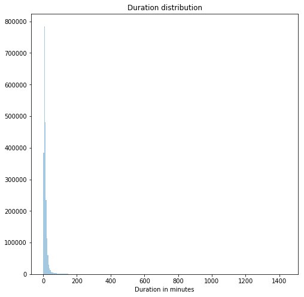

```python
plt.figure(figsize = (8,8))

sb.distplot(dfc['duration_minutes'], bins = bin_edges_01, kde = False)

plt.title('Duration distribution')
plt.xlabel('Duration in minutes');
```

Seems there are outliers in the duration distribution. Therefore, a limit is set.

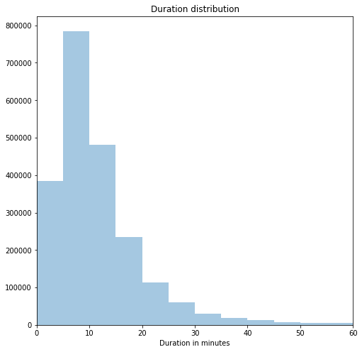

```python
plt.figure(figsize = (8,8))

sb.distplot(dfc['duration_minutes'], bins = bin_edges_01, kde = False)

plt.xlim(0,60)

plt.title('Duration distribution')
plt.xlabel('Duration in minutes');
```

**Conclusion:** The duration distribution is highly right skewed!

> The data has be be cleaned for the outliers before further analysis is conducted

**02_Distance distribution**

```python
bin_edges_02 = np.arange(0, dfc['distance'].max()+1000, 1000)
bin_edges_02
```

```
array([    0.,  1000.,  2000.,  3000.,  4000.,  5000.,  6000.,  7000.,
        8000.,  9000., 10000., 11000., 12000., 13000., 14000., 15000.,
       16000., 17000., 18000., 19000., 20000., 21000., 22000., 23000.,
       24000., 25000., 26000., 27000., 28000., 29000., 30000., 31000.,
       32000., 33000., 34000., 35000., 36000., 37000., 38000., 39000.,
       40000., 41000., 42000., 43000., 44000., 45000., 46000., 47000.,
       48000., 49000., 50000., 51000., 52000., 53000., 54000., 55000.,
       56000., 57000., 58000., 59000., 60000., 61000., 62000., 63000.,
       64000., 65000., 66000., 67000., 68000., 69000.])
```

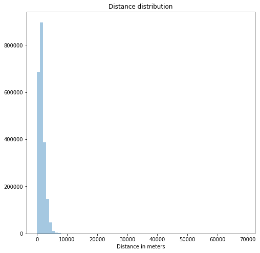

```python
plt.figure(figsize = (8,8))

sb.distplot(dfc['distance'], bins = bin_edges_02, kde = False)

plt.title('Distance distribution')
plt.xlabel('Distance in meters');
```

Seems like there are some outliers. Therefore, a limit is set.

```python
dfc['distance'].max()
```

```
68196.25331284529
```

Bin_edges have to be calculated newly since the bin edges above were used because of the outliers

```python
bin_edges_02_1 = np.arange(0, dfc['distance'].max()+1000, 200)
```

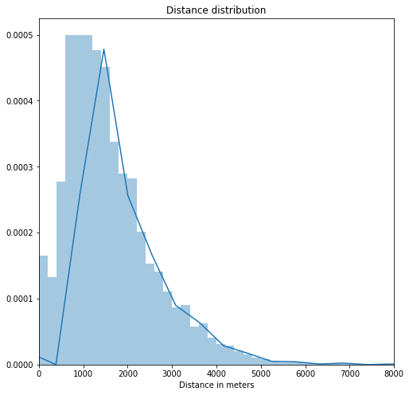

```python
plt.figure(figsize = (8,8))

sb.distplot(dfc['distance'], bins = bin_edges_02_1, kde = True)

plt.xlim(0,8000)

plt.title('Distance distribution')
plt.xlabel('Distance in meters');
```

> The data has be be cleaned for the outliers before further analysis

**03_Start and end station distribution**

Most start stations

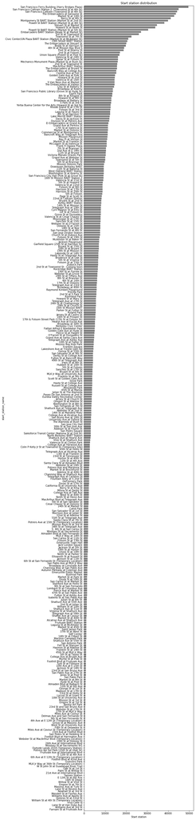

```python
plt.figure(figsize = (8,60))

sb.countplot(data = dfc, y = 'start_station_name', color = 'grey', order = dfc.start_station_name.value_counts().index)

plt.title('Start station distribution')
plt.xlabel('Start station');
```

```python
dfc.start_station_name.value_counts().head(50)
```

```
San Francisco Ferry Building (Harry Bridges Plaza)                 49617
San Francisco Caltrain Station 2  (Townsend St at 4th St)          44960
San Francisco Caltrain (Townsend St at 4th St)                     44242
The Embarcadero at Sansome St                                      43634
Market St at 10th St                                               42795
Berry St at 4th St                                                 41205
Montgomery St BART Station (Market St at 2nd St)                   39981
Powell St BART Station (Market St at 4th St)                       38160
Steuart St at Market St                                            34689
Howard St at Beale St                                              33827
Powell St BART Station (Market St at 5th St)                       30467
Embarcadero BART Station (Beale St at Market St)                   27141
3rd St at Townsend St                                              26076
Townsend St at 7th St                                              22523
Civic Center/UN Plaza BART Station (Market St at McAllister St)    21076
19th Street BART Station                                           20562
The Embarcadero at Steuart St                                      20042
Beale St at Harrison St                                            19893
4th St at Mission Bay Blvd S                                       19025
Post St at Kearny St                                               18792
2nd St at Folsom St                                                17018
Union Square (Powell St at Post St)                                16863
Valencia St at 24th St                                             16159
Spear St at Folsom St                                              16127
Mechanics Monument Plaza (Market St at Bush St)                    15949
2nd St at Townsend St                                              15776
MacArthur BART Station                                             15655
The Embarcadero at Bryant St                                       15646
Bancroft Way at College Ave                                        15319
Central Ave at Fell St                                             15298
Golden Gate Ave at Polk St                                         14673
Howard St at 2nd St                                                14661
Valencia St at 16th St                                             14541
S Van Ness Ave at Market St                                        14535
The Embarcadero at Vallejo St                                      14452
Clay St at Battery St                                              14233
Broadway at Kearny                                                 13707
San Francisco Public Library (Grove St at Hyde St)                 13660
Esprit Park                                                        13420
8th St at Ringold St                                               13309
Howard St at 8th St                                                13019
Broadway at Battery St                                             12985
S Park St at 3rd St                                                12803
Yerba Buena Center for the Arts (Howard St at 3rd St)              12679
Rhode Island St at 17th St                                         12625
Folsom St at 3rd St                                                12545
Laguna St at Hayes St                                              12404
4th St at Harrison St                                              12380
Lake Merritt BART Station                                          12212
Davis St at Jackson St                                             12057
Name: start_station_name, dtype: int64
```

```python
dfc.start_station_name.value_counts().head(50).sum() / dfc.start_station_name.value_counts().sum()
```

```
0.4906255813824976
```

Almost 50% of the rides start at the top 50 stations

Most end stations

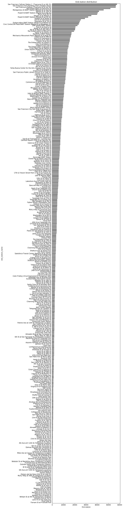

```python
plt.figure(figsize = (8,60))

sb.countplot(data = dfc, y = 'end_station_name', color = 'grey', order = dfc.end_station_name.value_counts().index)

plt.title('End station distribution')
plt.xlabel('End station');
```

```python
dfc.end_station_name.value_counts().head(50)
```

```
San Francisco Caltrain Station 2  (Townsend St at 4th St)          57549
San Francisco Ferry Building (Harry Bridges Plaza)                 56588
San Francisco Caltrain (Townsend St at 4th St)                     56492
The Embarcadero at Sansome St                                      51793
Montgomery St BART Station (Market St at 2nd St)                   45735
Market St at 10th St                                               41583
Powell St BART Station (Market St at 4th St)                       40460
Berry St at 4th St                                                 39947
Steuart St at Market St                                            34761
Powell St BART Station (Market St at 5th St)                       31977
Howard St at Beale St                                              29145
3rd St at Townsend St                                              25467
Townsend St at 7th St                                              24712
Embarcadero BART Station (Beale St at Market St)                   24118
Civic Center/UN Plaza BART Station (Market St at McAllister St)    23517
19th Street BART Station                                           22517
Post St at Kearny St                                               20667
Beale St at Harrison St                                            20431
4th St at Mission Bay Blvd S                                       20328
The Embarcadero at Steuart St                                      19424
Spear St at Folsom St                                              17250
MacArthur BART Station                                             17060
Mechanics Monument Plaza (Market St at Bush St)                    16687
Valencia St at 24th St                                             16538
2nd St at Townsend St                                              15918
Valencia St at 16th St                                             15713
Folsom St at 3rd St                                                15616
The Embarcadero at Vallejo St                                      15222
Clay St at Battery St                                              14977
Howard St at 2nd St                                                14520
The Embarcadero at Bryant St                                       14478
S Van Ness Ave at Market St                                        14109
Union Square (Powell St at Post St)                                13752
S Park St at 3rd St                                                13608
Golden Gate Ave at Polk St                                         13536
Downtown Berkeley BART                                             13507
Davis St at Jackson St                                             13263
Division St at Potrero Ave                                         13243
Esprit Park                                                        13225
Howard St at 8th St                                                13222
Laguna St at Hayes St                                              13164
Rhode Island St at 17th St                                         13030
El Embarcadero at Grand Ave                                        13030
2nd St at Folsom St                                                13014
4th St at Harrison St                                              12777
Yerba Buena Center for the Arts (Howard St at 3rd St)              12760
8th St at Ringold St                                               12439
Grand Ave at Perkins St                                            12422
San Francisco Public Library (Grove St at Hyde St)                 12270
Central Ave at Fell St                                             12261
Name: end_station_name, dtype: int64
```

```python
dfc.end_station_name.value_counts().head(50).sum() / dfc.end_station_name.value_counts().sum()
```

```
0.5110741277650782
```

More than 50% of the rides end at the top 50 stations

Check if start and end stations top 50 are the same

```python
start_stations_top50 = dfc.start_station_name.value_counts().head(50).index
end_stations_top50 = dfc.end_station_name.value_counts().head(50).index

for i in start_stations_top50:
    if i not in end_stations_top50:
        print (i)
```

```
Bancroft Way at College Ave
Broadway at Kearny
Broadway at Battery St
Lake Merritt BART Station
```

Nearly all of the top 50 start stations are in the top 50 end stations. Therefore, most of the traffic is between these top 50 start and end stations

Highest used routes

```python
# Groupby start station and end station

dfc_start_end = dfc.groupby(['start_station_name', 'end_station_name']).count()

dfc_start_end.reset_index(inplace = True)
dfc_start_end = dfc_start_end[['start_station_name', 'end_station_name', 'start_station_id']]

# Rename Column
dfc_start_end.rename(index=str, columns={"start_station_id": "count_of_drives"}, inplace = True)

dfc_start_end.sort_values(by = ['count_of_drives'], ascending = False).head(10)
```

|  | start_station_name | end_station_name | count_of_drives |
| --- | --- | --- | --- |
| 28898 | San Francisco Ferry Building (Harry Bridges Pl... | The Embarcadero at Sansome St | 10332 |
| 32325 | The Embarcadero at Sansome St | Steuart St at Market St | 6110 |
| 9170 | Berry St at 4th St | San Francisco Ferry Building (Harry Bridges Pl... | 5798 |
| 32319 | The Embarcadero at Sansome St | San Francisco Ferry Building (Harry Bridges Pl... | 5161 |
| 2452 | 19th Street BART Station | Grand Ave at Perkins St | 4632 |
| 17144 | Grand Ave at Perkins St | 19th Street BART Station | 4555 |
| 31162 | Steuart St at Market St | The Embarcadero at Sansome St | 4313 |
| 28798 | San Francisco Ferry Building (Harry Bridges Pl... | Berry St at 4th St | 4296 |
| 8662 | Bay Pl at Vernon St | 19th Street BART Station | 3818 |
| 22031 | Market St at 10th St | San Francisco Caltrain Station 2 (Townsend St... | 3628 |

**Conclustion:** Most of the drives start and end on very similar places. About 50% of all the bike rides are within the top 50 start and end stations. Most of the top stations are close to BART or Caltrain stations. A more detailed investigation for these stations and also a more detailed overview about the individual stations and the number of drives between them should be done in San Francisco to figure out the most important routes. However, this will not be a part of this analysis.

**04_Bike id distribution**

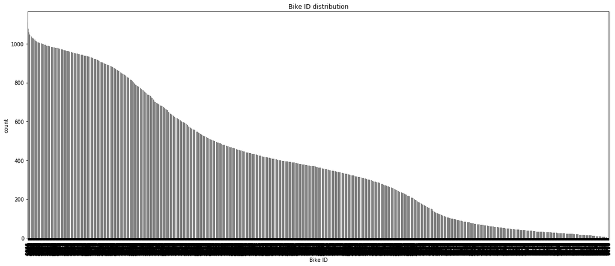

```python
plt.figure(figsize = (20,8))

sb.countplot(data = dfc, x = 'bike_id', color = 'grey', order = dfc.bike_id.value_counts().index)

plt.title('Bike ID distribution')
plt.xlabel('')
plt.xticks(rotation=90)

plt.xlabel('Bike ID');
```

```python
dfc.bike_id.value_counts().head(20)
```

```
3961    1109
1827    1087
126     1085
661     1083
746     1078
2185    1078
2457    1077
523     1065
232     1063
1738    1060
155     1059
647     1052
1161    1052
2774    1051
2228    1050
1665    1050
68      1048
2545    1046
2859    1046
2174    1046
Name: bike_id, dtype: int64
```

```python
dfc[dfc.bike_id == '3961']
```

|  | start_station_id | start_station_name | end_station_id | end_station_name | bike_id | user_type | member_birth_year | member_gender | bike_share_for_all_trip | start_date | start_time_ | end_date | end_time_ | duration_minutes | distance |
| --- | --- | --- | --- | --- | --- | --- | --- | --- | --- | --- | --- | --- | --- | --- | --- |
| 836579 | 139.0 | Garfield Square (25th St at Harrison St) | 36.0 | Folsom St at 3rd St | 3961 | Subscriber | 1988.0 | Male | No | 2018-09-19 | 08:22 | 2018-09-19 | 08:40 | 17.500000 | 3818.653678 |
| 838817 | 129.0 | Harrison St at 20th St | 139.0 | Garfield Square (25th St at Harrison St) | 3961 | Subscriber | 1993.0 | Female | Yes | 2018-09-18 | 19:22 | 2018-09-18 | 19:26 | 4.033333 | 872.560123 |
| 839039 | 109.0 | 17th St at Valencia St | 129.0 | Harrison St at 20th St | 3961 | Subscriber | 1989.0 | Male | No | 2018-09-18 | 18:57 | 2018-09-18 | 19:02 | 4.416667 | 961.559882 |
| 839212 | 124.0 | 19th St at Florida St | 109.0 | 17th St at Valencia St | 3961 | Subscriber | 1988.0 | Male | No | 2018-09-18 | 18:38 | 2018-09-18 | 18:49 | 11.016667 | 1028.350012 |
| 840199 | 61.0 | Howard St at 8th St | 124.0 | 19th St at Florida St | 3961 | Subscriber | 1996.0 | Male | No | 2018-09-18 | 17:35 | 2018-09-18 | 17:44 | 9.000000 | 1783.703496 |
| 840535 | 30.0 | San Francisco Caltrain (Townsend St at 4th St) | 61.0 | Howard St at 8th St | 3961 | Subscriber | 1995.0 | Male | No | 2018-09-18 | 17:14 | 2018-09-18 | 17:23 | 8.333333 | 1411.724136 |
| 840769 | 30.0 | San Francisco Caltrain (Townsend St at 4th St) | 30.0 | San Francisco Caltrain (Townsend St at 4th St) | 3961 | Subscriber | 1974.0 | Male | Yes | 2018-09-18 | 17:06 | 2018-09-18 | 17:08 | 1.750000 | 0.000000 |
| 840883 | 30.0 | San Francisco Caltrain (Townsend St at 4th St) | 30.0 | San Francisco Caltrain (Townsend St at 4th St) | 3961 | Subscriber | 1974.0 | Male | Yes | 2018-09-18 | 16:56 | 2018-09-18 | 16:59 | 2.283333 | 0.000000 |
| 840948 | 30.0 | San Francisco Caltrain (Townsend St at 4th St) | 30.0 | San Francisco Caltrain (Townsend St at 4th St) | 3961 | Subscriber | 1974.0 | Male | Yes | 2018-09-18 | 16:49 | 2018-09-18 | 16:52 | 3.783333 | 0.000000 |
| 841349 | 10.0 | Washington St at Kearny St | 30.0 | San Francisco Caltrain (Townsend St at 4th St) | 3961 | Subscriber | 1979.0 | Female | No | 2018-09-18 | 15:51 | 2018-09-18 | 16:03 | 11.383333 | 2247.291700 |
| 843288 | 3.0 | Powell St BART Station (Market St at 4th St) | 10.0 | Washington St at Kearny St | 3961 | Subscriber | 1990.0 | Male | No | 2018-09-18 | 09:24 | 2018-09-18 | 09:29 | 4.466667 | 1000.961012 |
| 843409 | 66.0 | 3rd St at Townsend St | 3.0 | Powell St BART Station (Market St at 4th St) | 3961 | Subscriber | 1996.0 | Male | No | 2018-09-18 | 09:13 | 2018-09-18 | 09:22 | 8.466667 | 1366.009893 |
| 843532 | 27.0 | Beale St at Harrison St | 66.0 | 3rd St at Townsend St | 3961 | Subscriber | 1980.0 | Male | No | 2018-09-18 | 09:07 | 2018-09-18 | 09:13 | 5.816667 | 1037.064975 |
| 843706 | 67.0 | San Francisco Caltrain Station 2 (Townsend St... | 27.0 | Beale St at Harrison St | 3961 | Subscriber | 1990.0 | Male | No | 2018-09-18 | 08:56 | 2018-09-18 | 09:02 | 5.950000 | 1307.935530 |
| 844115 | 102.0 | Irwin St at 8th St | 67.0 | San Francisco Caltrain Station 2 (Townsend St... | 3961 | Subscriber | nan | NaN | No | 2018-09-18 | 08:36 | 2018-09-18 | 08:40 | 4.266667 | 1140.240080 |
| 844346 | 43.0 | San Francisco Public Library (Grove St at Hyde... | 102.0 | Irwin St at 8th St | 3961 | Customer | 1967.0 | Male | No | 2018-09-18 | 08:16 | 2018-09-18 | 08:25 | 8.950000 | 1953.207051 |
| 844570 | 52.0 | McAllister St at Baker St | 43.0 | San Francisco Public Library (Grove St at Hyde... | 3961 | Subscriber | 1984.0 | Male | No | 2018-09-18 | 08:03 | 2018-09-18 | 08:11 | 7.766667 | 2287.360499 |
| 844696 | 3.0 | Powell St BART Station (Market St at 4th St) | 52.0 | McAllister St at Baker St | 3961 | Subscriber | 1993.0 | Female | No | 2018-09-18 | 07:50 | 2018-09-18 | 08:02 | 12.083333 | 3402.096086 |
| 845095 | 29.0 | O'Farrell St at Divisadero St | 3.0 | Powell St BART Station (Market St at 4th St) | 3961 | Subscriber | 1995.0 | Male | No | 2018-09-18 | 06:58 | 2018-09-18 | 07:16 | 17.833333 | 3074.468439 |
| 845559 | 105.0 | 16th St at Prosper St | 29.0 | O'Farrell St at Divisadero St | 3961 | Subscriber | 1967.0 | Male | No | 2018-09-17 | 22:19 | 2018-09-17 | 22:27 | 8.816667 | 2120.825011 |
| 845732 | 70.0 | Central Ave at Fell St | 105.0 | 16th St at Prosper St | 3961 | Subscriber | 1981.0 | Male | No | 2018-09-17 | 21:13 | 2018-09-17 | 21:22 | 9.066667 | 1488.053606 |
| 846722 | 67.0 | San Francisco Caltrain Station 2 (Townsend St... | 70.0 | Central Ave at Fell St | 3961 | Subscriber | 1985.0 | Male | No | 2018-09-17 | 18:33 | 2018-09-17 | 18:52 | 18.850000 | 4312.161694 |
| 848803 | 16.0 | Steuart St at Market St | 30.0 | San Francisco Caltrain (Townsend St at 4th St) | 3961 | Subscriber | 1987.0 | Male | No | 2018-09-17 | 16:11 | 2018-09-17 | 16:20 | 8.766667 | 1947.361004 |
| 849377 | 6.0 | The Embarcadero at Sansome St | 16.0 | Steuart St at Market St | 3961 | Subscriber | 1979.0 | Male | Yes | 2018-09-17 | 14:07 | 2018-09-17 | 14:13 | 5.750000 | 1412.753663 |
| 849952 | 37.0 | 2nd St at Folsom St | 6.0 | The Embarcadero at Sansome St | 3961 | Subscriber | 1987.0 | Male | No | 2018-09-17 | 11:38 | 2018-09-17 | 11:50 | 11.933333 | 2286.564116 |
| 851510 | 21.0 | Montgomery St BART Station (Market St at 2nd St) | 37.0 | 2nd St at Folsom St | 3961 | Subscriber | 1984.0 | Male | No | 2018-09-17 | 08:33 | 2018-09-17 | 08:37 | 4.416667 | 669.343126 |
| 851857 | 90.0 | Townsend St at 7th St | 21.0 | Montgomery St BART Station (Market St at 2nd St) | 3961 | Subscriber | 1987.0 | Female | No | 2018-09-17 | 07:59 | 2018-09-17 | 08:12 | 12.766667 | 2067.662525 |
| 852140 | 17.0 | Embarcadero BART Station (Beale St at Market St) | 90.0 | Townsend St at 7th St | 3961 | Subscriber | 1985.0 | Male | No | 2018-09-17 | 07:36 | 2018-09-17 | 07:48 | 12.016667 | 2403.989475 |
| 852295 | 28.0 | The Embarcadero at Bryant St | 17.0 | Embarcadero BART Station (Beale St at Market St) | 3961 | Subscriber | 1971.0 | Male | No | 2018-09-17 | 07:20 | 2018-09-17 | 07:24 | 3.366667 | 972.145020 |
| 852511 | 343.0 | Bryant St at 2nd St | 28.0 | The Embarcadero at Bryant St | 3961 | Subscriber | 1986.0 | Male | No | 2018-09-17 | 06:28 | 2018-09-17 | 06:31 | 2.600000 | 655.160905 |
| ... | ... | ... | ... | ... | ... | ... | ... | ... | ... | ... | ... | ... | ... | ... | ... |
| 2072652 | 323.0 | Broadway at Kearny | 70.0 | Central Ave at Fell St | 3961 | Customer | 1995.0 | Male | No | 2018-04-26 | 15:22 | 2018-04-26 | 15:53 | 30.833333 | 4350.259436 |
| 2072987 | 59.0 | S Van Ness Ave at Market St | 323.0 | Broadway at Kearny | 3961 | Subscriber | 1959.0 | Male | No | 2018-04-26 | 14:06 | 2018-04-26 | 14:20 | 14.116667 | 2818.251633 |
| 2073167 | 86.0 | Market St at Dolores St | 59.0 | S Van Ness Ave at Market St | 3961 | Subscriber | 1971.0 | Male | No | 2018-04-26 | 13:12 | 2018-04-26 | 13:19 | 7.500000 | 924.553095 |
| 2073450 | 321.0 | 5th at Folsom | 86.0 | Market St at Dolores St | 3961 | Subscriber | 1969.0 | Male | Yes | 2018-04-26 | 11:47 | 2018-04-26 | 12:04 | 17.200000 | 2414.019854 |
| 2077802 | 34.0 | Father Alfred E Boeddeker Park | 321.0 | 5th at Folsom | 3961 | Subscriber | 1990.0 | Male | Yes | 2018-04-25 | 17:31 | 2018-04-25 | 17:36 | 4.100000 | 926.502896 |
| 2078465 | 85.0 | Church St at Duboce Ave | 34.0 | Father Alfred E Boeddeker Park | 3961 | Subscriber | 1980.0 | Male | Yes | 2018-04-25 | 16:17 | 2018-04-25 | 16:30 | 12.716667 | 2135.119685 |
| 2078774 | 5.0 | Powell St BART Station (Market St at 5th St) | 85.0 | Church St at Duboce Ave | 3961 | Subscriber | 1980.0 | Male | Yes | 2018-04-25 | 15:35 | 2018-04-25 | 15:46 | 11.833333 | 2383.415171 |
| 2078828 | 23.0 | The Embarcadero at Steuart St | 5.0 | Powell St BART Station (Market St at 5th St) | 3961 | Subscriber | 1975.0 | Male | No | 2018-04-25 | 15:18 | 2018-04-25 | 15:31 | 12.750000 | 1748.425662 |
| 2078919 | 45.0 | 5th St at Howard St | 23.0 | The Embarcadero at Steuart St | 3961 | Subscriber | 1969.0 | Male | No | 2018-04-25 | 14:58 | 2018-04-25 | 15:10 | 12.100000 | 1644.097906 |
| 2079023 | 93.0 | 4th St at Mission Bay Blvd S | 45.0 | 5th St at Howard St | 3961 | Subscriber | 1987.0 | Male | No | 2018-04-25 | 14:39 | 2018-04-25 | 14:47 | 8.050000 | 1758.190570 |
| 2079057 | 93.0 | 4th St at Mission Bay Blvd S | 93.0 | 4th St at Mission Bay Blvd S | 3961 | Subscriber | 1960.0 | Male | No | 2018-04-25 | 14:18 | 2018-04-25 | 14:38 | 19.450000 | 0.000000 |
| 2079185 | 3.0 | Powell St BART Station (Market St at 4th St) | 93.0 | 4th St at Mission Bay Blvd S | 3961 | Subscriber | 1984.0 | Female | No | 2018-04-25 | 13:57 | 2018-04-25 | 14:06 | 9.133333 | 2144.522703 |
| 2079219 | 59.0 | S Van Ness Ave at Market St | 3.0 | Powell St BART Station (Market St at 4th St) | 3961 | Subscriber | 1983.0 | Male | Yes | 2018-04-25 | 13:47 | 2018-04-25 | 13:55 | 7.816667 | 1782.827218 |
| 2079376 | 27.0 | Beale St at Harrison St | 59.0 | S Van Ness Ave at Market St | 3961 | Subscriber | 1969.0 | Male | No | 2018-04-25 | 13:00 | 2018-04-25 | 13:14 | 14.150000 | 2802.842408 |
| 2079436 | 22.0 | Howard St at Beale St | 27.0 | Beale St at Harrison St | 3961 | Subscriber | 1980.0 | Male | No | 2018-04-25 | 12:44 | 2018-04-25 | 12:59 | 15.183333 | 308.786690 |
| 2079658 | 37.0 | 2nd St at Folsom St | 22.0 | Howard St at Beale St | 3961 | Subscriber | 1974.0 | Male | No | 2018-04-25 | 12:06 | 2018-04-25 | 12:09 | 3.566667 | 540.048230 |
| 2080169 | 21.0 | Montgomery St BART Station (Market St at 2nd St) | 37.0 | 2nd St at Folsom St | 3961 | Subscriber | 1986.0 | Male | No | 2018-04-25 | 10:04 | 2018-04-25 | 10:09 | 4.500000 | 669.343126 |
| 2080531 | 124.0 | 19th St at Florida St | 21.0 | Montgomery St BART Station (Market St at 2nd St) | 3961 | Subscriber | 1965.0 | Male | No | 2018-04-25 | 09:05 | 2018-04-25 | 09:27 | 21.883333 | 3356.177738 |
| 2081003 | 223.0 | 16th St Mission BART Station 2 | 124.0 | 19th St at Florida St | 3961 | Subscriber | 1983.0 | Male | No | 2018-04-25 | 08:46 | 2018-04-25 | 08:51 | 4.950000 | 948.127877 |
| 2081375 | 125.0 | 20th St at Bryant St | 223.0 | 16th St Mission BART Station 2 | 3961 | Subscriber | 1961.0 | Male | No | 2018-04-25 | 08:18 | 2018-04-25 | 08:24 | 6.500000 | 1093.448057 |
| 2081674 | 134.0 | Valencia St at 24th St | 125.0 | 20th St at Bryant St | 3961 | Subscriber | 1983.0 | Female | No | 2018-04-25 | 07:50 | 2018-04-25 | 07:57 | 6.583333 | 1211.183317 |
| 2081889 | 146.0 | 30th St at San Jose Ave | 134.0 | Valencia St at 24th St | 3961 | Subscriber | 1992.0 | Male | No | 2018-04-25 | 07:18 | 2018-04-25 | 07:23 | 4.850000 | 1144.878476 |
| 2083135 | 132.0 | 24th St at Chattanooga St | 146.0 | 30th St at San Jose Ave | 3961 | Subscriber | 1997.0 | Male | No | 2018-04-24 | 18:39 | 2018-04-24 | 19:05 | 26.650000 | 1097.565681 |
| 2083507 | 132.0 | 24th St at Chattanooga St | 132.0 | 24th St at Chattanooga St | 3961 | Subscriber | 1976.0 | Male | No | 2018-04-24 | 18:13 | 2018-04-24 | 18:30 | 17.583333 | 0.000000 |
| 2083874 | 147.0 | 29th St at Tiffany Ave | 132.0 | 24th St at Chattanooga St | 3961 | Subscriber | 1997.0 | Male | No | 2018-04-24 | 17:37 | 2018-04-24 | 18:01 | 23.800000 | 972.509630 |
| 2084718 | 98.0 | Valencia St at 16th St | 147.0 | 29th St at Tiffany Ave | 3961 | Subscriber | nan | NaN | No | 2018-04-24 | 16:43 | 2018-04-24 | 16:50 | 7.466667 | 2329.449858 |
| 2084843 | 76.0 | McCoppin St at Valencia St | 98.0 | Valencia St at 16th St | 3961 | Subscriber | 1981.0 | Male | No | 2018-04-24 | 16:31 | 2018-04-24 | 16:34 | 3.350000 | 735.347376 |
| 2085248 | 60.0 | 8th St at Ringold St | 76.0 | McCoppin St at Valencia St | 3961 | Subscriber | 1993.0 | Male | No | 2018-04-24 | 14:53 | 2018-04-24 | 15:06 | 12.750000 | 1186.222988 |
| 2085328 | 58.0 | Market St at 10th St | 60.0 | 8th St at Ringold St | 3961 | Subscriber | 1994.0 | Male | No | 2018-04-24 | 14:40 | 2018-04-24 | 14:45 | 4.300000 | 736.904588 |
| 2085537 | 74.0 | Laguna St at Hayes St | 58.0 | Market St at 10th St | 3961 | Subscriber | 1993.0 | Female | No | 2018-04-24 | 13:30 | 2018-04-24 | 13:38 | 8.016667 | 780.730601 |

1109 rows × 15 columns

**Conclusion:** The utilization rate of the bikes is most probably highly dependend on the places the bikes are. Therefore, bikes with a hihger utilization has to be maintained more often. Alternatively, bikes with a very high utalization rate could be exchanged for bikes with a lower rate.

**05_Member birth year and gender distribution**

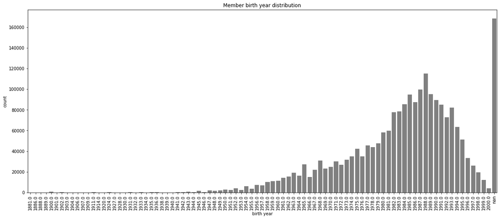

```python
plt.figure(figsize = (20,8))

sb.countplot(data = dfc, x = 'member_birth_year', color = 'grey')

plt.title('Member birth year distribution')
plt.xticks(rotation=90)
plt.xlabel('birth year');
```

This data set sould also be cleaned for the members that were born before 1940 because they would be about 80 years today.

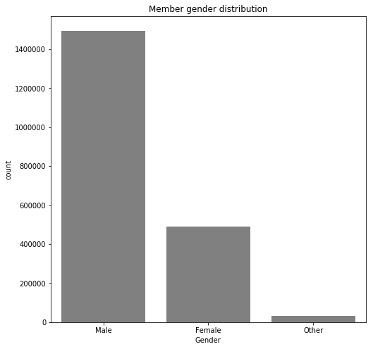

```python
plt.figure(figsize = (8,8))

sb.countplot(data = dfc, x = 'member_gender', color = 'grey')

plt.title('Member gender distribution')
plt.xlabel('Gender');
```

**Conclusion:** Apparently more male than female use the bike service. The age distribution is slighly shifted towards younger people.

**06_Rides over time**

```python
dfc.info(null_counts= True)
```

```
<class 'pandas.core.frame.DataFrame'>
RangeIndex: 2181963 entries, 0 to 2181962
Data columns (total 15 columns):
start_station_id           2181963 non-null object
start_station_name         2171548 non-null object
end_station_id             2181963 non-null object
end_station_name           2171548 non-null object
bike_id                    2181963 non-null object
user_type                  2181963 non-null object
member_birth_year          2181963 non-null object
member_gender              2013774 non-null object
bike_share_for_all_trip    2181963 non-null object
start_date                 2181963 non-null datetime64[ns]
start_time_                2181963 non-null object
end_date                   2181963 non-null datetime64[ns]
end_time_                  2181963 non-null object
duration_minutes           2181963 non-null float64
distance                   2181963 non-null float64
dtypes: datetime64[ns](2), float64(2), object(11)
memory usage: 249.7+ MB
```

New column with month and year is nessecary to aggregate on a monthly level

```python
dfc['year'] = pd.DatetimeIndex(dfc['start_date']).year
dfc['month'] = pd.DatetimeIndex(dfc['start_date']).month
dfc['year'] = dfc['year']
dfc['month'] = dfc['month']
dfc['year_and_month'] = dfc['year'].astype(str) +'-'+ dfc['month'].astype(str)
dfc['year_and_month'] = pd.to_datetime(dfc['year_and_month'])
```

```python
dfc.head()
```

|  | start_station_id | start_station_name | end_station_id | end_station_name | bike_id | user_type | member_birth_year | member_gender | bike_share_for_all_trip | start_date | start_time_ | end_date | end_time_ | duration_minutes | distance | year | month | year_and_month |
| --- | --- | --- | --- | --- | --- | --- | --- | --- | --- | --- | --- | --- | --- | --- | --- | --- | --- | --- |
| 0 | 74 | Laguna St at Hayes St | 43 | San Francisco Public Library (Grove St at Hyde... | 96 | Customer | 1987.0 | Male | No | 2017-12-31 | 16:57 | 2018-01-01 | 15:12 | 1335.166667 | 944.873770 | 2017 | 12 | 2017-12-01 |
| 1 | 284 | Yerba Buena Center for the Arts (Howard St at ... | 96 | Dolores St at 15th St | 88 | Customer | 1965.0 | Female | No | 2017-12-31 | 15:56 | 2018-01-01 | 13:49 | 1313.333333 | 3071.136593 | 2017 | 12 | 2017-12-01 |
| 2 | 245 | Downtown Berkeley BART | 245 | Downtown Berkeley BART | 1094 | Customer | nan | NaN | No | 2017-12-31 | 22:45 | 2018-01-01 | 11:28 | 762.800000 | 0.000000 | 2017 | 12 | 2017-12-01 |
| 3 | 60 | 8th St at Ringold St | 5 | Powell St BART Station (Market St at 5th St) | 2831 | Customer | nan | NaN | No | 2017-12-31 | 17:31 | 2018-01-01 | 10:47 | 1036.200000 | 1044.743656 | 2017 | 12 | 2017-12-01 |
| 4 | 239 | Bancroft Way at Telegraph Ave | 247 | Fulton St at Bancroft Way | 3167 | Subscriber | 1997.0 | Female | No | 2017-12-31 | 14:23 | 2018-01-01 | 02:29 | 726.716667 | 637.770511 | 2017 | 12 | 2017-12-01 |

```python
dfc.info()
```

```
<class 'pandas.core.frame.DataFrame'>
RangeIndex: 2181963 entries, 0 to 2181962
Data columns (total 18 columns):
start_station_id           object
start_station_name         object
end_station_id             object
end_station_name           object
bike_id                    object
user_type                  object
member_birth_year          object
member_gender              object
bike_share_for_all_trip    object
start_date                 datetime64[ns]
start_time_                object
end_date                   datetime64[ns]
end_time_                  object
duration_minutes           float64
distance                   float64
year                       int64
month                      int64
year_and_month             datetime64[ns]
dtypes: datetime64[ns](3), float64(2), int64(2), object(11)
memory usage: 299.6+ MB
```

Drop unnessecary columns

```python
dfc.drop(['month', 'year'], axis = 1, inplace = True)
```

Use the start_date as time

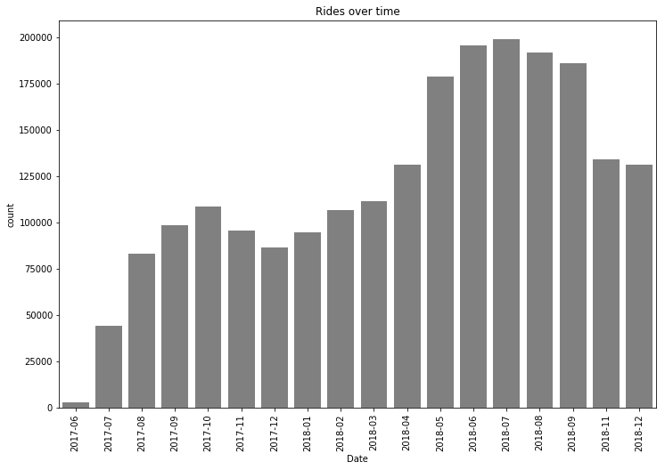

```python
fig, ax = plt.subplots(figsize = (12,8))

# We need to draw the canvas, otherwise the labels won't be positioned and won't have values yet.
fig.canvas.draw()

# Plot
sb.countplot(data = dfc, x = 'year_and_month', color = 'grey')

# The labels have to be adjusted
labels = [item.get_text() for item in ax.get_xticklabels()]

label_list = []
for i in labels:
    label_list.append(i[0:7])

labels = label_list

# Design
ax.set_xticklabels(labels)

plt.title('Rides over time')
plt.xticks(rotation=90)
plt.xlabel('Date')

plt.show();
```

**Conclusion:** There is an incrase due to the time of operation of the service. Moreover, in the summer months more rides are conducted.

**07_Duration and distance scatterplot**

```python
dfc[['distance', 'duration_minutes']].info(null_counts=True)
```

```
<class 'pandas.core.frame.DataFrame'>
RangeIndex: 2181963 entries, 0 to 2181962
Data columns (total 2 columns):
distance            2181963 non-null float64
duration_minutes    2181963 non-null float64
dtypes: float64(2)
memory usage: 33.3 MB
```

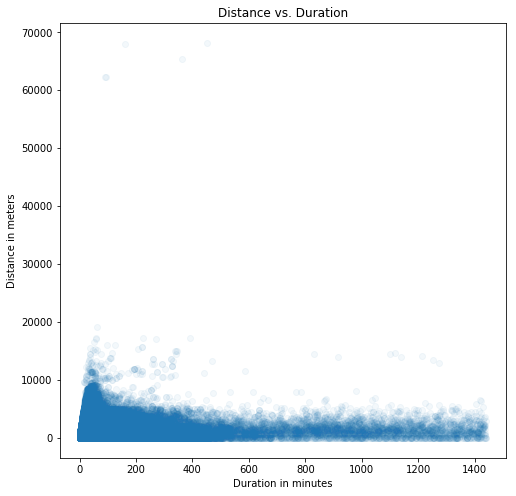

```python
plt.figure(figsize = (8,8))

plt.scatter(data = dfc, x = 'duration_minutes', y = 'distance', alpha = 1/20)

plt.title('Distance vs. Duration')
plt.xlabel('Duration in minutes')
plt.ylabel('Distance in meters');
```

It seems that very often the distance traveled is 0

```python
dfc_distance = dfc[dfc.distance == 0][['start_station_name', 'end_station_name']]
dfc_distance.dropna(inplace = True)
dfc_distance.reset_index(drop = True, inplace = True)
dfc_distance.info()
```

```
<class 'pandas.core.frame.DataFrame'>
RangeIndex: 65571 entries, 0 to 65570
Data columns (total 2 columns):
start_station_name    65571 non-null object
end_station_name      65571 non-null object
dtypes: object(2)
memory usage: 1.0+ MB
```

```python
distance_zero = (dfc_distance.start_station_name == dfc_distance.end_station_name)
```

```python
dfc_distance['start_equals_end'] = distance_zero
dfc_distance[dfc_distance.start_equals_end == False]
```

|  | start_station_name | end_station_name | start_equals_end |
| --- | --- | --- | --- |

**Conclusion:** It seems there is no correlation between distance and duration. Although, outliers are making an analysis difficult. The distance equals null is due to the calculation because the distance between the start and end station is calculated

**Save data**

```python
# pickle saves dataframe inkluding the data type information etc.
dfc.to_pickle('cleaned_dataframe_new.pkl')
```

# Clean data after initial visualizations

**Clean the data**

- Remove duration outliers
- Remove distance outliers
- Clean for missing values

Copy dataframe

```python
dfc_new = pd.read_pickle('cleaned_dataframe_new.pkl')
```

```python
dfcc = dfc_new.copy()
```

```python
dfcc.info(null_counts= True)
```

```
<class 'pandas.core.frame.DataFrame'>
RangeIndex: 2181963 entries, 0 to 2181962
Data columns (total 16 columns):
start_station_id           2181963 non-null object
start_station_name         2171548 non-null object
end_station_id             2181963 non-null object
end_station_name           2171548 non-null object
bike_id                    2181963 non-null object
user_type                  2181963 non-null object
member_birth_year          2181963 non-null object
member_gender              2013774 non-null object
bike_share_for_all_trip    2181963 non-null object
start_date                 2181963 non-null datetime64[ns]
start_time_                2181963 non-null object
end_date                   2181963 non-null datetime64[ns]
end_time_                  2181963 non-null object
duration_minutes           2181963 non-null float64
distance                   2181963 non-null float64
year_and_month             2181963 non-null datetime64[ns]
dtypes: datetime64[ns](3), float64(2), object(11)
memory usage: 266.4+ MB
```

**01_Define**  
Remove duration outliers from the dataset

**Code**

```python
dfcc.duration_minutes.describe()
```

```
count    2.181963e+06
mean     1.532807e+01
std      4.499705e+01
min      1.016667e+00
25%      5.950000e+00
50%      9.416667e+00
75%      1.480000e+01
max      1.439483e+03
Name: duration_minutes, dtype: float64
```

Calculate the IQR and mean

```python
q75_dur, q25_dur = np.percentile(dfcc.duration_minutes, [75 ,25])
iqr_dur = q75_dur - q25_dur
mean_dur = dfcc.duration_minutes.mean()
iqr_dur, mean_dur
```

```
(8.850000000000001, 15.328066317654054)
```

Remove all outliers greater than 2x IQR

```python
limit_dur = mean_dur + 2 * iqr_dur
limit_dur
```

```
33.02806631765406
```

Overview about the remaining data

```python
dfcc.duration_minutes[dfcc.duration_minutes < limit_dur].count(), dfcc.duration_minutes.count(), dfcc.duration_minutes[dfc.duration_minutes < limit_dur].count() / dfc.duration_minutes.count()
```

```
(2079974, 2181963, 0.9532581441573482)
```

Remove outliers

```python
dfcc = dfcc[dfcc.duration_minutes < limit_dur]
dfcc.reset_index(inplace = True, drop = True)
```

**Test**

```python
dfcc.info(null_counts= True)
```

```
<class 'pandas.core.frame.DataFrame'>
RangeIndex: 2079974 entries, 0 to 2079973
Data columns (total 16 columns):
start_station_id           2079974 non-null object
start_station_name         2071102 non-null object
end_station_id             2079974 non-null object
end_station_name           2071102 non-null object
bike_id                    2079974 non-null object
user_type                  2079974 non-null object
member_birth_year          2079974 non-null object
member_gender              1949101 non-null object
bike_share_for_all_trip    2079974 non-null object
start_date                 2079974 non-null datetime64[ns]
start_time_                2079974 non-null object
end_date                   2079974 non-null datetime64[ns]
end_time_                  2079974 non-null object
duration_minutes           2079974 non-null float64
distance                   2079974 non-null float64
year_and_month             2079974 non-null datetime64[ns]
dtypes: datetime64[ns](3), float64(2), object(11)
memory usage: 253.9+ MB
```

```python
dfcc.head(1)
```

|  | start_station_id | start_station_name | end_station_id | end_station_name | bike_id | user_type | member_birth_year | member_gender | bike_share_for_all_trip | start_date | start_time_ | end_date | end_time_ | duration_minutes | distance | year_and_month |
| --- | --- | --- | --- | --- | --- | --- | --- | --- | --- | --- | --- | --- | --- | --- | --- | --- |
| 0 | 14 | Clay St at Battery St | 27 | Beale St at Harrison St | 558 | Subscriber | 1980.0 | Female | No | 2017-12-31 | 23:53 | 2018-01-01 | 00:19 | 25.733333 | 1050.379422 | 2017-12-01 |

**02_Define**  
Remove distance outliers from the dataset

**Code**

```python
dfcc.distance.describe()
```

```
count    2.079974e+06
mean     1.583453e+03
std      9.733685e+02
min      0.000000e+00
25%      8.860449e+02
50%      1.378911e+03
75%      2.073876e+03
max      1.331256e+04
Name: distance, dtype: float64
```

```python
q75_dis, q25_dis = np.percentile(dfcc.distance, [75 ,25])
iqr_dis = q75_dis - q25_dis
mean_dis = dfcc.distance.mean()
iqr_dis, mean_dis
```

```
(1187.8314887919946, 1583.4532326798203)
```

Remove all outliers greater than 2x IQR

```python
limit_dis = mean_dis + 2 * iqr_dis
limit_dis
```

```
3959.1162102638095
```

Overview about the remaining data

```python
dfcc.distance[dfcc.distance < limit_dis].count(), dfcc.distance.count(), dfcc.distance[dfc.distance < limit_dis].count() / dfc.distance.count()
```

```
(2023867, 2079974, 0.9241100788601824)
```

```python
dfcc = dfcc[dfcc.distance < limit_dis]
dfcc.reset_index(inplace = True, drop = True)
```

**Test**

```python
dfcc.info(null_counts= True)
```

```
<class 'pandas.core.frame.DataFrame'>
RangeIndex: 2023867 entries, 0 to 2023866
Data columns (total 16 columns):
start_station_id           2023867 non-null object
start_station_name         2015099 non-null object
end_station_id             2023867 non-null object
end_station_name           2015099 non-null object
bike_id                    2023867 non-null object
user_type                  2023867 non-null object
member_birth_year          2023867 non-null object
member_gender              1895798 non-null object
bike_share_for_all_trip    2023867 non-null object
start_date                 2023867 non-null datetime64[ns]
start_time_                2023867 non-null object
end_date                   2023867 non-null datetime64[ns]
end_time_                  2023867 non-null object
duration_minutes           2023867 non-null float64
distance                   2023867 non-null float64
year_and_month             2023867 non-null datetime64[ns]
dtypes: datetime64[ns](3), float64(2), object(11)
memory usage: 247.1+ MB
```

**03_Define**  
Clean for missing values

**Code**

```python
dfcc.info(null_counts= True)
```

```
<class 'pandas.core.frame.DataFrame'>
RangeIndex: 2023867 entries, 0 to 2023866
Data columns (total 16 columns):
start_station_id           2023867 non-null object
start_station_name         2015099 non-null object
end_station_id             2023867 non-null object
end_station_name           2015099 non-null object
bike_id                    2023867 non-null object
user_type                  2023867 non-null object
member_birth_year          2023867 non-null object
member_gender              1895798 non-null object
bike_share_for_all_trip    2023867 non-null object
start_date                 2023867 non-null datetime64[ns]
start_time_                2023867 non-null object
end_date                   2023867 non-null datetime64[ns]
end_time_                  2023867 non-null object
duration_minutes           2023867 non-null float64
distance                   2023867 non-null float64
year_and_month             2023867 non-null datetime64[ns]
dtypes: datetime64[ns](3), float64(2), object(11)
memory usage: 247.1+ MB
```

Drop all data with missing values

```python
dfcc.dropna(inplace = True)
dfcc.reset_index(drop = True, inplace = True)
```

**Test**

```python
dfcc.info(null_counts= True)
```

```
<class 'pandas.core.frame.DataFrame'>
RangeIndex: 1887258 entries, 0 to 1887257
Data columns (total 16 columns):
start_station_id           1887258 non-null object
start_station_name         1887258 non-null object
end_station_id             1887258 non-null object
end_station_name           1887258 non-null object
bike_id                    1887258 non-null object
user_type                  1887258 non-null object
member_birth_year          1887258 non-null object
member_gender              1887258 non-null object
bike_share_for_all_trip    1887258 non-null object
start_date                 1887258 non-null datetime64[ns]
start_time_                1887258 non-null object
end_date                   1887258 non-null datetime64[ns]
end_time_                  1887258 non-null object
duration_minutes           1887258 non-null float64
distance                   1887258 non-null float64
year_and_month             1887258 non-null datetime64[ns]
dtypes: datetime64[ns](3), float64(2), object(11)
memory usage: 230.4+ MB
```

Calculate the data that was removed

```python
dfcc.start_station_id.count() / dfc.start_station_id.count()
```

```
0.8649358398836278
```

More than 86% of the original data is still in the dataframe

```python
# pickle saves dataframe inkluding the data type information etc.
dfcc.to_pickle('cleaned_dataframe2.pkl')
```

# Insights and visualizations part II

**Different exploratory plots**

- Correlation plots
- Distribution plots

```python
dfcc = pd.read_pickle('cleaned_dataframe2.pkl')
```

```python
dfcc.info(null_counts= True)
```

```
<class 'pandas.core.frame.DataFrame'>
RangeIndex: 1887258 entries, 0 to 1887257
Data columns (total 16 columns):
start_station_id           1887258 non-null object
start_station_name         1887258 non-null object
end_station_id             1887258 non-null object
end_station_name           1887258 non-null object
bike_id                    1887258 non-null object
user_type                  1887258 non-null object
member_birth_year          1887258 non-null object
member_gender              1887258 non-null object
bike_share_for_all_trip    1887258 non-null object
start_date                 1887258 non-null datetime64[ns]
start_time_                1887258 non-null object
end_date                   1887258 non-null datetime64[ns]
end_time_                  1887258 non-null object
duration_minutes           1887258 non-null float64
distance                   1887258 non-null float64
year_and_month             1887258 non-null datetime64[ns]
dtypes: datetime64[ns](3), float64(2), object(11)
memory usage: 230.4+ MB
```

```python
dfcc.head(1)
```

|  | start_station_id | start_station_name | end_station_id | end_station_name | bike_id | user_type | member_birth_year | member_gender | bike_share_for_all_trip | start_date | start_time_ | end_date | end_time_ | duration_minutes | distance | year_and_month |
| --- | --- | --- | --- | --- | --- | --- | --- | --- | --- | --- | --- | --- | --- | --- | --- | --- |
| 0 | 14 | Clay St at Battery St | 27 | Beale St at Harrison St | 558 | Subscriber | 1980.0 | Female | No | 2017-12-31 | 23:53 | 2018-01-01 | 00:19 | 25.733333 | 1050.379422 | 2017-12-01 |

```python
dfcc.columns
```

```
Index(['start_station_id', 'start_station_name', 'end_station_id',
       'end_station_name', 'bike_id', 'user_type', 'member_birth_year',
       'member_gender', 'bike_share_for_all_trip', 'start_date', 'start_time_',
       'end_date', 'end_time_', 'duration_minutes', 'distance',
       'year_and_month'],
      dtype='object')
```

```python
sample = dfcc.sample(1500)
sample.reset_index(inplace = True, drop = True)
```

```python
sample.info(null_counts=True)
```

```
<class 'pandas.core.frame.DataFrame'>
RangeIndex: 1500 entries, 0 to 1499
Data columns (total 16 columns):
start_station_id           1500 non-null object
start_station_name         1500 non-null object
end_station_id             1500 non-null object
end_station_name           1500 non-null object
bike_id                    1500 non-null object
user_type                  1500 non-null object
member_birth_year          1500 non-null object
member_gender              1500 non-null object
bike_share_for_all_trip    1500 non-null object
start_date                 1500 non-null datetime64[ns]
start_time_                1500 non-null object
end_date                   1500 non-null datetime64[ns]
end_time_                  1500 non-null object
duration_minutes           1500 non-null float64
distance                   1500 non-null float64
year_and_month             1500 non-null datetime64[ns]
dtypes: datetime64[ns](3), float64(2), object(11)
memory usage: 187.6+ KB
```

```python
sample.head(1)
```

|  | start_station_id | start_station_name | end_station_id | end_station_name | bike_id | user_type | member_birth_year | member_gender | bike_share_for_all_trip | start_date | start_time_ | end_date | end_time_ | duration_minutes | distance | year_and_month |
| --- | --- | --- | --- | --- | --- | --- | --- | --- | --- | --- | --- | --- | --- | --- | --- | --- |
| 0 | 17.0 | Embarcadero BART Station (Beale St at Market St) | 81.0 | Berry St at 4th St | 952 | Subscriber | 1992.0 | Male | No | 2018-04-28 | 21:44 | 2018-04-28 | 21:58 | 13.85 | 1849.506233 | 2018-04-01 |

```python
sample.describe()
```

|  | duration_minutes | distance |
| --- | --- | --- |
| count | 1500.000000 | 1500.000000 |
| mean | 9.832778 | 1475.095110 |
| std | 5.720560 | 815.661993 |
| min | 1.016667 | 0.000000 |
| 25% | 5.650000 | 899.436512 |
| 50% | 8.550000 | 1309.979198 |
| 75% | 12.816667 | 1959.396540 |
| max | 32.483333 | 3929.875539 |

```python
dfcc.describe()
```

|  | duration_minutes | distance |
| --- | --- | --- |
| count | 1.887258e+06 | 1.887258e+06 |
| mean | 9.889793e+00 | 1.501770e+03 |
| std | 5.745226e+00 | 8.316035e+02 |
| min | 1.016667e+00 | 0.000000e+00 |
| 25% | 5.633333e+00 | 8.795636e+02 |
| 50% | 8.666667e+00 | 1.360239e+03 |
| 75% | 1.286667e+01 | 2.002646e+03 |
| max | 3.301667e+01 | 3.958777e+03 |

Remove the datapoints with distance = 0

```python
sample_dis_nonzero = sample[sample.distance != 0]
sample_dis_nonzero.reset_index(drop = True, inplace = True)
```

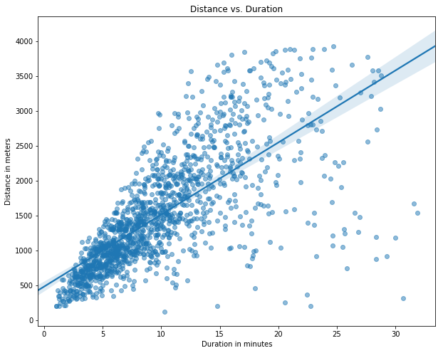

```python
plt.figure(figsize = (10,8))

sb.regplot(data = sample_dis_nonzero, x = 'duration_minutes', y = 'distance', fit_reg = True,
           x_jitter = 0.2, y_jitter = 0.2, scatter_kws = {'alpha' : 1/2})

plt.title('Distance vs. Duration')
plt.xlabel('Duration in minutes')
plt.ylabel('Distance in meters');
```

```python
sample_dis_nonzero.corr()
```

|  | duration_minutes | distance |
| --- | --- | --- |
| duration_minutes | 1.000000 | 0.720247 |
| distance | 0.720247 | 1.000000 |

**Conclusion:** After the data was cleaned duration and distance seem to have a correlation.

Investigation of the gender

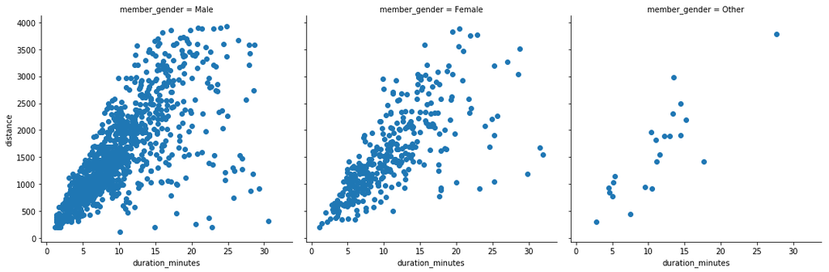

```python
g = sb.FacetGrid(data = sample_dis_nonzero, col = 'member_gender', size = 5,
                margin_titles = True)
g.map(plt.scatter, 'duration_minutes', 'distance')
```

Investigation of the bike share for all trip

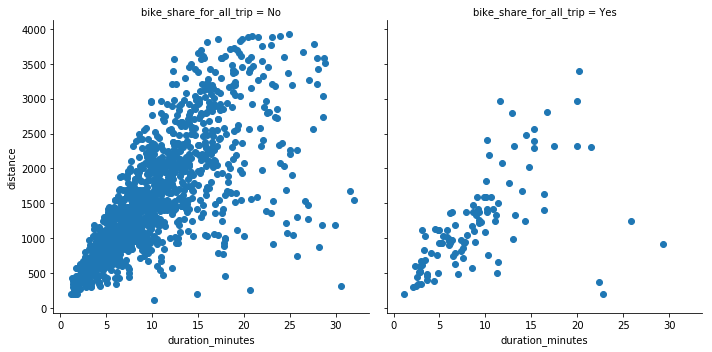

```python
g = sb.FacetGrid(data = sample_dis_nonzero, col = 'bike_share_for_all_trip', size = 5,
                margin_titles = True)
g.map(plt.scatter, 'duration_minutes', 'distance')
```

Ivestigation fo the user type

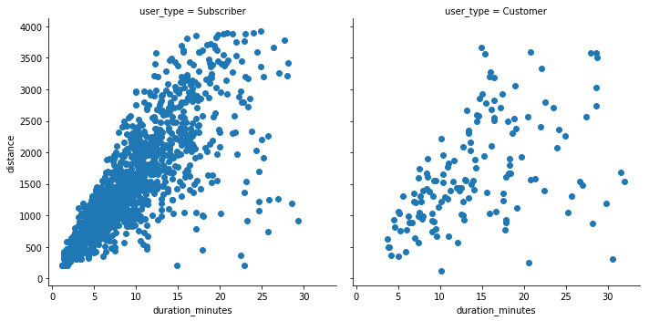

```python
g = sb.FacetGrid(data = sample_dis_nonzero, col = 'user_type', size = 5,
                margin_titles = True)
g.map(plt.scatter, 'duration_minutes', 'distance')
```